# SPY ETF ML Trading Strategy Analysis

Algorithmic Trading System

2025-07-15

# Data Load

The numeric suffix for each data set represents 1. ATR multiplier 2. Trade timeout duration (minutes)

```r
data1_3 = read.csv("../csvs/train1_3.csv")     # 1-3 minute holding period
```

# Data exploration for 1_3

```r
summary(data1_3)
```

```
##       X2                 Open           Close            High
##  Length:21492       Min.   :416.3   Min.   :416.3   Min.   :416.4
##  Class :character   1st Qu.:428.8   1st Qu.:428.8   1st Qu.:428.8
##  Mode  :character   Median :435.8   Median :435.8   Median :435.9
##                     Mean   :434.4   Mean   :434.4   Mean   :434.5
##                     3rd Qu.:439.8   3rd Qu.:439.8   3rd Qu.:439.8
##                     Max.   :450.4   Max.   :450.4   Max.   :450.4
##       Low            Volume             ATR                 PL
##  Min.   :416.2   Min.   :      1   Min.   :0.006399   Min.   :0.0000
##  1st Qu.:428.7   1st Qu.:   2016   1st Qu.:0.067450   1st Qu.:0.0000
##  Median :435.7   Median :  54740   Median :0.106248   Median :0.0000
##  Mean   :434.3   Mean   :  83707   Mean   :0.130528   Mean   :0.4414
##  3rd Qu.:439.7   3rd Qu.: 110482   3rd Qu.:0.166756   3rd Qu.:1.0000
##  Max.   :450.2   Max.   :4816391   Max.   :1.285800   Max.   :1.0000
##     pl_value             SMA_k7          SMA_k20          SMA_k50
##  Min.   :-845.0000   Min.   :0.9966   Min.   :0.9938   Min.   :0.9930
##  1st Qu.: -90.2023   1st Qu.:0.9998   1st Qu.:0.9997   1st Qu.:0.9996
##  Median : -20.0000   Median :1.0000   Median :1.0000   Median :1.0001
##  Mean   :   0.5364   Mean   :1.0000   Mean   :1.0000   Mean   :1.0001
##  3rd Qu.:  90.0000   3rd Qu.:1.0002   3rd Qu.:1.0003   3rd Qu.:1.0006
##  Max.   :1610.0000   Max.   :1.0047   Max.   :1.0048   Max.   :1.0057
```

## View Summary and shape

### ATR Multiplier (λ - Lambda)

#### Mean Price Calculation:

$$\mu_T =
\frac{\sum_{i=T-k}^{T}(OHLC_i)}{k}$$

#### Modified ATR Formula:

$$ATR_T =
\sqrt{\frac{\sum_{i=T-k}^{T}(OHLC_i - \mu_T)^2}{k}}$$
Controls the sensitivity to market volatility:

### pl_value

It is determined by iterating through the dataframe and seeing if the price reaches take profit or stop loss first. It assumes a 1000 share position size.

#### Profit-to-Loss Ratio (χ - Chi)

Asymmetric risk-reward ratio: - **Default**: 1.5 (profit targets 50% wider than loss targets)

- **Profit Target**: $Price_T + λ × χ × ATR$
- **Loss Target**: $Price_T - λ × ATR$

#### Timeout Period (t)

Maximum holding period before forced exit:

- **Purpose**: Prevents indefinite position holding
- **Logic**: If neither target hit within t periods, compare exit price to entry
- **Classification**: Profit (1) if $Price_{T+t} > Price_T$, Loss (0) otherwise

### SMA

$$SMA_k =
\frac{Open_T}{\frac{1}{k}\sum_{i=T-k}^{T-1}Close_i}$$

- $T$ = current time period
- $k$ = lookback period
- Hypothetically, values > 1.0 indicate price above historical average (bullish)
- Values < 1.0 indicate price below historical average (bearish)

#### Multi-Timeframe Analysis

The system calculates SMA for three periods:

- **SMA_7**: Short-term momentum (1 week of 5-min bars)
- **SMA_20**: Medium-term trend (1 month of daily closes)
- **SMA_50**: Long-term trend (quarterly trend)

#### Signal Interpretation

- **Trend Confirmation**: Multiple SMAs above 1.0 = strong uptrend
- **Momentum Divergence**: SMA_7 > SMA_20 > SMA_50 = accelerating uptrend
- **Mean Reversion**: Extreme SMA values (>1.05 or <0.95) suggest potential reversal

See mkt_data.ipynb for information ### PL: Encodes 0 if `pl_value` < 0

Split train-test data

```r
seed_num = 213
set.seed(seed_num) # reproducibility
data1_3$norm_volume = (data1_3$Volume - mean(data1_3$Volume))/sd(data1_3$Volume)
ind = sample(1:nrow(data1_3),0.75*nrow(data1_3))
train = data1_3[ind,]
test = data1_3[-ind,]
```

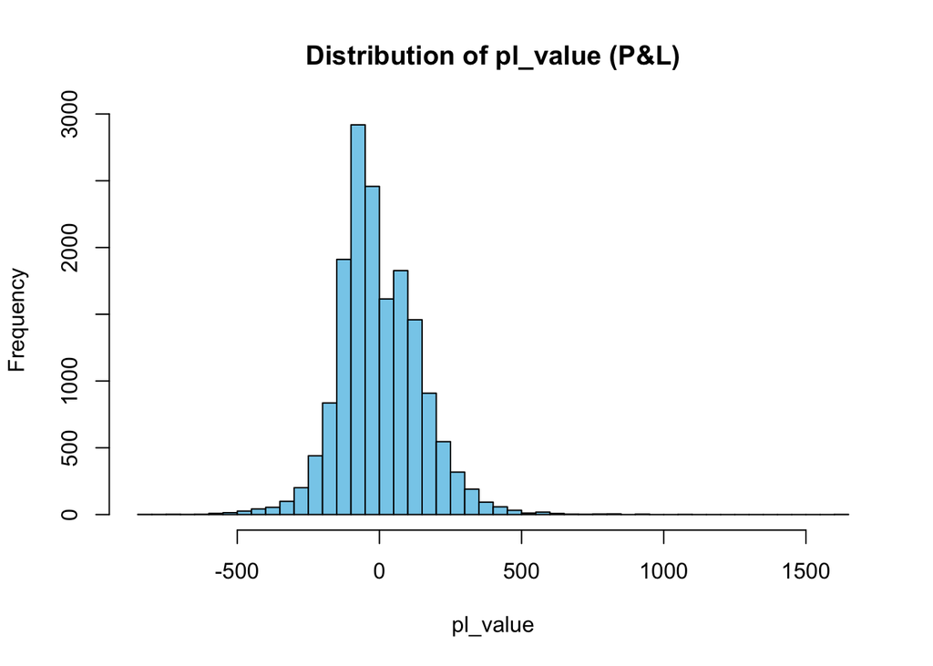

```r
hist(train$pl_value, breaks = 50, col = "skyblue", main = "Distribution of pl_value (P&L)", xlab = "pl_value")
```

## Assess correlation

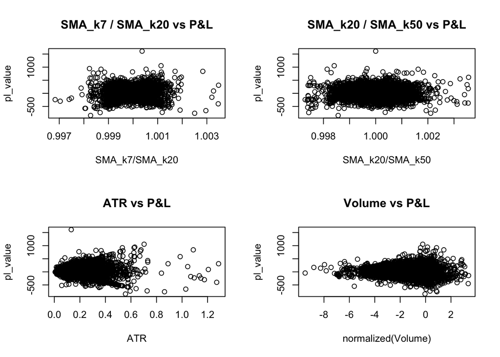

```r
par(mfrow=c(2,2))
plot(train$SMA_k7/train$SMA_k20, train$pl_value, main="SMA_k7 / SMA_k20 vs P&L", xlab="SMA_k7/SMA_k20", ylab="pl_value")
plot(train$SMA_k20/train$SMA_k50, train$pl_value, main="SMA_k20 / SMA_k50 vs P&L", xlab="SMA_k20/SMA_k50", ylab="pl_value")
plot(train$ATR, train$pl_value, main="ATR vs P&L", xlab="ATR", ylab="pl_value")
plot(log(train$norm_volume), train$pl_value, main="Volume vs P&L", xlab="normalized(Volume)", ylab="pl_value")
```

```r
par(mfrow=c(1,1))
```

ATR shows to have a weak correlation. I think the interaction of predictors with each other will be more important.

## Visualize predictor correlation matrix

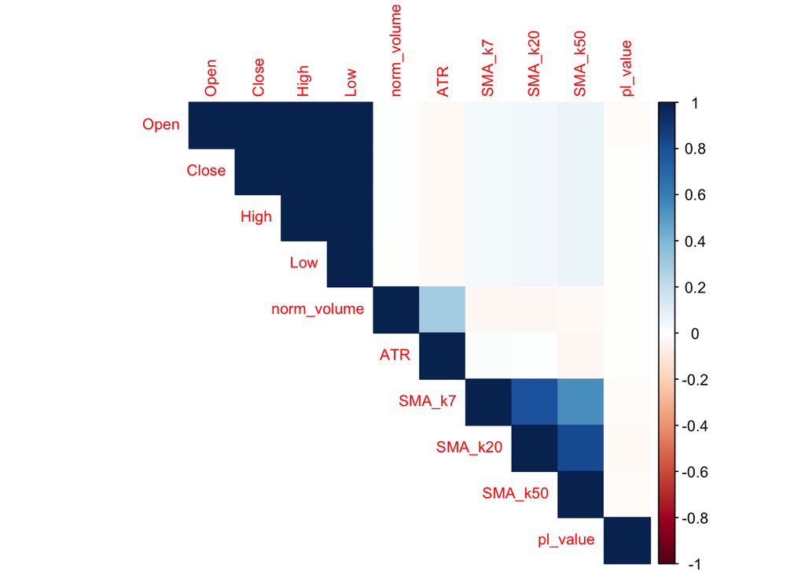

```r
library(corrplot)
numeric_vars <- train[, c("Open", "Close", "High", "Low", "norm_volume", "ATR", "SMA_k7", "SMA_k20", "SMA_k50", "pl_value")]
cor_matrix <- cor(numeric_vars, use="complete.obs")

corrplot(cor_matrix, method = "color", type = "upper", tl.cex = 0.8)
```

## Log regression

Use all parameters and all interactions initially

```r
glm1 = glm(
  data = train,
  PL ~ ATR + SMA_k7 + SMA_k20 + SMA_k50 + norm_volume +
       ATR:SMA_k7 +
       ATR:SMA_k20 +
       ATR:SMA_k50 +
       ATR:SMA_k7:SMA_k20 +
       ATR:SMA_k7:SMA_k50 +
       ATR:SMA_k20:SMA_k50 +
       ATR:SMA_k7:SMA_k20:SMA_k50 +
       norm_volume:ATR +
       norm_volume:SMA_k7 +
       norm_volume:SMA_k20 +
       norm_volume:SMA_k50 +
       norm_volume:ATR:SMA_k7 +
       norm_volume:ATR:SMA_k20 +
       norm_volume:ATR:SMA_k50 +
       norm_volume:SMA_k7:SMA_k20 +
       norm_volume:SMA_k7:SMA_k50 +
       norm_volume:SMA_k20:SMA_k50 +
       norm_volume:ATR:SMA_k7:SMA_k20 +
       norm_volume:ATR:SMA_k7:SMA_k50 +
       norm_volume:ATR:SMA_k20:SMA_k50 +
       norm_volume:ATR:SMA_k7:SMA_k20:SMA_k50,
  family = "binomial"
)
```

### Assess accuracy

```r
summary(glm1)
```

```
##
## Call:
## glm(formula = PL ~ ATR + SMA_k7 + SMA_k20 + SMA_k50 + norm_volume +
##     ATR:SMA_k7 + ATR:SMA_k20 + ATR:SMA_k50 + ATR:SMA_k7:SMA_k20 +
##     ATR:SMA_k7:SMA_k50 + ATR:SMA_k20:SMA_k50 + ATR:SMA_k7:SMA_k20:SMA_k50 +
##     norm_volume:ATR + norm_volume:SMA_k7 + norm_volume:SMA_k20 +
##     norm_volume:SMA_k50 + norm_volume:ATR:SMA_k7 + norm_volume:ATR:SMA_k20 +
##     norm_volume:ATR:SMA_k50 + norm_volume:SMA_k7:SMA_k20 + norm_volume:SMA_k7:SMA_k50 +
##     norm_volume:SMA_k20:SMA_k50 + norm_volume:ATR:SMA_k7:SMA_k20 +
##     norm_volume:ATR:SMA_k7:SMA_k50 + norm_volume:ATR:SMA_k20:SMA_k50 +
##     norm_volume:ATR:SMA_k7:SMA_k20:SMA_k50, family = "binomial",
##     data = train)
##
## Coefficients:
##                                          Estimate Std. Error z value Pr(>|z|)
## (Intercept)                             7.141e+01  9.228e+01   0.774  0.43902
## ATR                                    -7.997e+07  5.275e+07  -1.516  0.12950
## SMA_k7                                 -3.994e+02  1.457e+02  -2.742  0.00611
## SMA_k20                                 3.469e+02  1.414e+02   2.453  0.01416
## SMA_k50                                -1.938e+01  6.485e+01  -0.299  0.76504
## norm_volume                             2.937e+03  6.251e+04   0.047  0.96252
## ATR:SMA_k7                              7.980e+07  5.273e+07   1.513  0.13023
## ATR:SMA_k20                             7.991e+07  5.279e+07   1.514  0.13007
## ATR:SMA_k50                             8.030e+07  5.267e+07   1.525  0.12733
## ATR:norm_volume                         4.502e+07  2.624e+07   1.716  0.08618
## SMA_k7:norm_volume                     -1.013e+05  8.826e+04  -1.148  0.25094
## SMA_k20:norm_volume                     3.479e+05  1.587e+05   2.192  0.02835
## SMA_k50:norm_volume                    -2.527e+05  1.218e+05  -2.075  0.03801
## ATR:SMA_k7:SMA_k20                     -7.974e+07  5.277e+07  -1.511  0.13079
## ATR:SMA_k7:SMA_k50                     -8.013e+07  5.265e+07  -1.522  0.12805
## ATR:SMA_k20:SMA_k50                    -8.024e+07  5.270e+07  -1.523  0.12788
## ATR:SMA_k7:norm_volume                 -4.491e+07  2.622e+07  -1.713  0.08679
## ATR:SMA_k20:norm_volume                -4.541e+07  2.624e+07  -1.731  0.08351
## ATR:SMA_k50:norm_volume                -4.487e+07  2.632e+07  -1.705  0.08821
## SMA_k7:SMA_k20:norm_volume             -2.495e+05  1.494e+05  -1.671  0.09478
## SMA_k7:SMA_k50:norm_volume              3.514e+05  1.371e+05   2.564  0.01034
## SMA_k20:SMA_k50:norm_volume            -9.870e+04  5.308e+04  -1.859  0.06296
## ATR:SMA_k7:SMA_k20:SMA_k50              8.007e+07  5.269e+07   1.520  0.12859
## ATR:SMA_k7:SMA_k20:norm_volume          4.530e+07  2.622e+07   1.727  0.08409
## ATR:SMA_k7:SMA_k50:norm_volume          4.476e+07  2.630e+07   1.702  0.08884
```

[output cut: 25 more lines]

```
## ATR:SMA_k7:SMA_k20:SMA_k50
## ATR:SMA_k7:SMA_k20:norm_volume         .
## ATR:SMA_k7:SMA_k50:norm_volume         .
## ATR:SMA_k20:SMA_k50:norm_volume        .
## ATR:SMA_k7:SMA_k20:SMA_k50:norm_volume .
## ---
## Signif. codes:  0 '***' 0.001 '**' 0.01 '*' 0.05 '.' 0.1 ' ' 1
##
## (Dispersion parameter for binomial family taken to be 1)
##
##     Null deviance: 22118  on 16118  degrees of freedom
## Residual deviance: 22013  on 16092  degrees of freedom
## AIC: 22067
##
## Number of Fisher Scoring iterations: 6
```

### Residuals analysis

Regular residual plots don’t make sense in glm. Dunn and Gordon (2018) introduce quantile residuals for discrete response variables. Their primary benefits are they do not show weird patterns (due to variable’s discreteness). They are available in R via statmod::qresid().

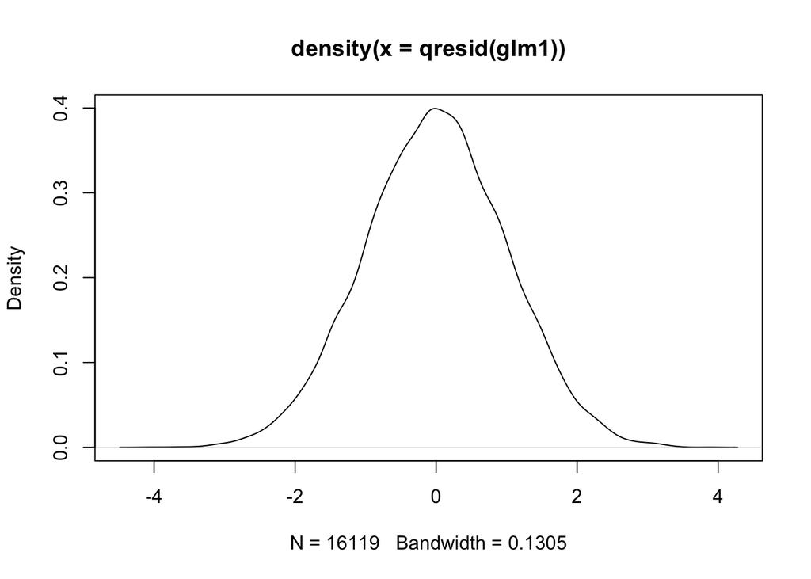

```r
library(statmod)
plot(density(qresid(glm1)))
```

```r
glm_step <- step(glm1, direction = "both")
```

```
## Start:  AIC=22067.2
## PL ~ ATR + SMA_k7 + SMA_k20 + SMA_k50 + norm_volume + ATR:SMA_k7 +
##     ATR:SMA_k20 + ATR:SMA_k50 + ATR:SMA_k7:SMA_k20 + ATR:SMA_k7:SMA_k50 +
##     ATR:SMA_k20:SMA_k50 + ATR:SMA_k7:SMA_k20:SMA_k50 + norm_volume:ATR +
##     norm_volume:SMA_k7 + norm_volume:SMA_k20 + norm_volume:SMA_k50 +
##     norm_volume:ATR:SMA_k7 + norm_volume:ATR:SMA_k20 + norm_volume:ATR:SMA_k50 +
##     norm_volume:SMA_k7:SMA_k20 + norm_volume:SMA_k7:SMA_k50 +
##     norm_volume:SMA_k20:SMA_k50 + norm_volume:ATR:SMA_k7:SMA_k20 +
##     norm_volume:ATR:SMA_k7:SMA_k50 + norm_volume:ATR:SMA_k20:SMA_k50 +
##     norm_volume:ATR:SMA_k7:SMA_k20:SMA_k50
##
##                                          Df Deviance   AIC
## <none>                                         22013 22067
## - ATR:SMA_k7:SMA_k20:SMA_k50:norm_volume  1    22017 22069
```

```r
summary(glm_step)
```

```
##
## Call:
## glm(formula = PL ~ ATR + SMA_k7 + SMA_k20 + SMA_k50 + norm_volume +
##     ATR:SMA_k7 + ATR:SMA_k20 + ATR:SMA_k50 + ATR:SMA_k7:SMA_k20 +
##     ATR:SMA_k7:SMA_k50 + ATR:SMA_k20:SMA_k50 + ATR:SMA_k7:SMA_k20:SMA_k50 +
##     norm_volume:ATR + norm_volume:SMA_k7 + norm_volume:SMA_k20 +
##     norm_volume:SMA_k50 + norm_volume:ATR:SMA_k7 + norm_volume:ATR:SMA_k20 +
##     norm_volume:ATR:SMA_k50 + norm_volume:SMA_k7:SMA_k20 + norm_volume:SMA_k7:SMA_k50 +
##     norm_volume:SMA_k20:SMA_k50 + norm_volume:ATR:SMA_k7:SMA_k20 +
##     norm_volume:ATR:SMA_k7:SMA_k50 + norm_volume:ATR:SMA_k20:SMA_k50 +
##     norm_volume:ATR:SMA_k7:SMA_k20:SMA_k50, family = "binomial",
##     data = train)
##
## Coefficients:
##                                          Estimate Std. Error z value Pr(>|z|)
## (Intercept)                             7.141e+01  9.228e+01   0.774  0.43902
## ATR                                    -7.997e+07  5.275e+07  -1.516  0.12950
## SMA_k7                                 -3.994e+02  1.457e+02  -2.742  0.00611
## SMA_k20                                 3.469e+02  1.414e+02   2.453  0.01416
## SMA_k50                                -1.938e+01  6.485e+01  -0.299  0.76504
## norm_volume                             2.937e+03  6.251e+04   0.047  0.96252
## ATR:SMA_k7                              7.980e+07  5.273e+07   1.513  0.13023
## ATR:SMA_k20                             7.991e+07  5.279e+07   1.514  0.13007
## ATR:SMA_k50                             8.030e+07  5.267e+07   1.525  0.12733
## ATR:norm_volume                         4.502e+07  2.624e+07   1.716  0.08618
## SMA_k7:norm_volume                     -1.013e+05  8.826e+04  -1.148  0.25094
## SMA_k20:norm_volume                     3.479e+05  1.587e+05   2.192  0.02835
## SMA_k50:norm_volume                    -2.527e+05  1.218e+05  -2.075  0.03801
## ATR:SMA_k7:SMA_k20                     -7.974e+07  5.277e+07  -1.511  0.13079
## ATR:SMA_k7:SMA_k50                     -8.013e+07  5.265e+07  -1.522  0.12805
## ATR:SMA_k20:SMA_k50                    -8.024e+07  5.270e+07  -1.523  0.12788
## ATR:SMA_k7:norm_volume                 -4.491e+07  2.622e+07  -1.713  0.08679
## ATR:SMA_k20:norm_volume                -4.541e+07  2.624e+07  -1.731  0.08351
## ATR:SMA_k50:norm_volume                -4.487e+07  2.632e+07  -1.705  0.08821
## SMA_k7:SMA_k20:norm_volume             -2.495e+05  1.494e+05  -1.671  0.09478
## SMA_k7:SMA_k50:norm_volume              3.514e+05  1.371e+05   2.564  0.01034
## SMA_k20:SMA_k50:norm_volume            -9.870e+04  5.308e+04  -1.859  0.06296
## ATR:SMA_k7:SMA_k20:SMA_k50              8.007e+07  5.269e+07   1.520  0.12859
## ATR:SMA_k7:SMA_k20:norm_volume          4.530e+07  2.622e+07   1.727  0.08409
## ATR:SMA_k7:SMA_k50:norm_volume          4.476e+07  2.630e+07   1.702  0.08884
```

[output cut: 25 more lines]

```
## ATR:SMA_k7:SMA_k20:SMA_k50
## ATR:SMA_k7:SMA_k20:norm_volume         .
## ATR:SMA_k7:SMA_k50:norm_volume         .
## ATR:SMA_k20:SMA_k50:norm_volume        .
## ATR:SMA_k7:SMA_k20:SMA_k50:norm_volume .
## ---
## Signif. codes:  0 '***' 0.001 '**' 0.01 '*' 0.05 '.' 0.1 ' ' 1
##
## (Dispersion parameter for binomial family taken to be 1)
##
##     Null deviance: 22118  on 16118  degrees of freedom
## Residual deviance: 22013  on 16092  degrees of freedom
## AIC: 22067
##
## Number of Fisher Scoring iterations: 6
```

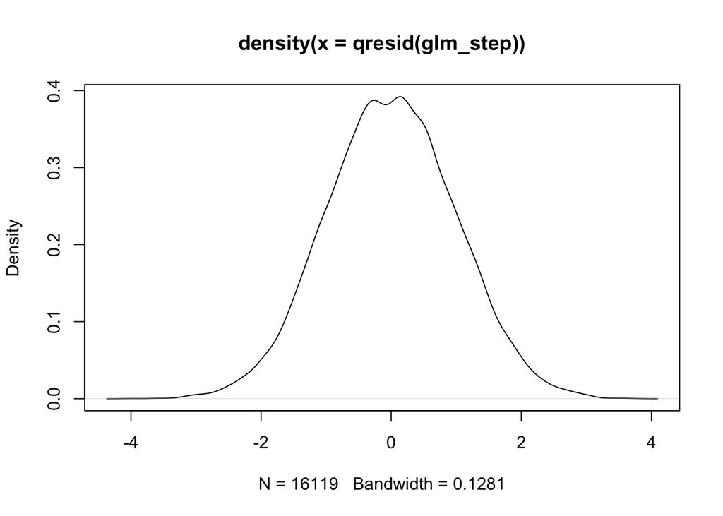

```r
plot(density(qresid(glm_step)))
```

This is still a lot of predictors, let’s try and do some subset selection

```r
library(glmnet)
# Get interaction matrix
X <- model.matrix(PL ~ (ATR + SMA_k7 + SMA_k20 + SMA_k50 + norm_volume)^3, data = train)[, -1]
y <- train$PL
cvfit <- cv.glmnet(X, y, family = "binomial", alpha = 1)

# Get model with lowest Cross Validation error
lasso_coef <- coef(cvfit, s = "lambda.min")
selected_vars <- rownames(lasso_coef)[lasso_coef[,1] != 0][-1]  # exclude intercept
selected_vars
```

```
## [1] "ATR"                 "norm_volume"         "ATR:SMA_k7"
## [4] "SMA_k50:norm_volume"
```

These are a lot fewer than earlier, let’s fit this conservative model

```r
glm_formula <- as.formula(paste("PL ~", paste(selected_vars, collapse = " + ")))
glm_cons <- glm(glm_formula, data = train, family = "binomial")
summary(glm_cons)
```

```
##
## Call:
## glm(formula = glm_formula, family = "binomial", data = train)
##
## Coefficients:
##                      Estimate Std. Error z value Pr(>|z|)
## (Intercept)          -0.37419    0.02796 -13.382   <2e-16 ***
## ATR                 -41.54800  153.21990  -0.271    0.786
## norm_volume           6.64180   12.80194   0.519    0.604
## ATR:SMA_k7           42.58200  153.21015   0.278    0.781
## norm_volume:SMA_k50  -6.67177   12.80731  -0.521    0.602
## ---
## Signif. codes:  0 '***' 0.001 '**' 0.01 '*' 0.05 '.' 0.1 ' ' 1
##
## (Dispersion parameter for binomial family taken to be 1)
##
##     Null deviance: 22118  on 16118  degrees of freedom
## Residual deviance: 22082  on 16114  degrees of freedom
## AIC: 22092
##
## Number of Fisher Scoring iterations: 4
```

### Assess performance

```r
pred_glm = ifelse(predict(glm_step,test,type="response")>0.5,1,0)
winrate = mean(pred_glm == test$PL)
print(winrate)
```

```
## [1] 0.5585334
```

```r
pred_glm_cons = ifelse(predict(glm_cons,test,type="response")>0.5,1,0)
winrate = mean(pred_glm_cons == test$PL)
print(winrate)
```

```
## [1] 0.5592779
```

Simulate 1000 trading simulations with random buy indicators and see if winrate if better than it. `p = 0.05`. This is to weed out strategies that don’t perform better than random chance.

```r
# Baseline comparison: coin flip vs accuracy

n <- nrow(test)

# Simulate coin flips (baseline)
baseline_accuracy = c()
for (i in 1:1000) {
  set.seed(i)
  coin_flips <- rbinom(n, size = 1, prob = 0.5)
  baseline_accuracy <- c(mean(coin_flips == test$PL), baseline_accuracy)
}
set.seed(seed_num) # reproducibility
cat("Coin toss simulations that performed better than strategy :",length(baseline_accuracy[baseline_accuracy>winrate]) / length(baseline_accuracy))
```

```
## Coin toss simulations that performed better than strategy : 0
```

```r
# Use normal approximation

cat("\nWinrate p value:",pnorm(winrate, mean(baseline_accuracy), sd(baseline_accuracy), lower.tail = F))
```

```
##
## Winrate p value: 2.369495e-18
```

This is definitely below the p value.

### Buy threshold

We need to determine when to buy based on the threshold. This improves the win rate at the cost of fewer trades. This will miss out on a lot of winning trades too (False negatives). But to succeed at trading we need to minimize false positives. Precision, or $\frac{TP}{FP+TP}$ is much more important. “For estimating a binomial proportion, at least 10 successes and 10 failures is recommended for normal approximation intervals.” Reference: Agresti, A. (2013). Categorical Data Analysis (3rd ed.)

```r
# Define thresholds
probs <- 10^seq(-2, -10, length.out = 9)

# Calculate mean and standard deviation of fitted values
fit_mean <- mean(glm_step$fitted.values)
fit_sd <- sd(glm_step$fitted.values)

# Loop through probabilities and evaluate predictions
prob_with_best_winrate = 0.05 # init
best_winrate = 0
for (prob in probs) {
  threshold <- qnorm(1 - prob, mean = fit_mean, sd = fit_sd)
  pred_glm <- ifelse(predict(glm_step, train, type = "response") > threshold, 1, 0)

  true_positive <- sum(pred_glm == 1 & train$PL == 1)
  false_positive <- sum(pred_glm == 1 & train$PL == 0)
  total_predicted_positive <- sum(pred_glm == 1)
  if ((true_positive + false_positive) < 30) {
    break # CLT
  }
  # Avoid division by zero
  winrate <- if (total_predicted_positive > 0) {
    true_positive / total_predicted_positive
  } else {
    NA
  }
  if (winrate > best_winrate) {
    best_winrate = winrate
    prob_with_best_winrate = prob
  }

  cat(sprintf("Prob = %.5f | TP = %d | FP = %d | Winrate = %.3f\n",
              prob, true_positive, false_positive, winrate))
}
```

```
## Prob = 0.01000 | TP = 170 | FP = 140 | Winrate = 0.548
## Prob = 0.00100 | TP = 95 | FP = 78 | Winrate = 0.549
## Prob = 0.00010 | TP = 69 | FP = 48 | Winrate = 0.590
## Prob = 0.00001 | TP = 49 | FP = 29 | Winrate = 0.628
## Prob = 0.00000 | TP = 43 | FP = 19 | Winrate = 0.694
## Prob = 0.00000 | TP = 32 | FP = 12 | Winrate = 0.727
## Prob = 0.00000 | TP = 29 | FP = 8 | Winrate = 0.784
## Prob = 0.00000 | TP = 26 | FP = 6 | Winrate = 0.812
## Prob = 0.00000 | TP = 26 | FP = 4 | Winrate = 0.867
```

```r
best_threshold = qnorm(1 - prob_with_best_winrate, mean = fit_mean, sd = fit_sd)
cat("Best winrate", best_winrate*100)
```

```
## Best winrate 86.66667
```

```r
cat("\nProbability with highest precision", prob_with_best_winrate)
```

```
##
## Probability with highest precision 1e-10
```

```r
cat("\nThreshold", best_threshold)
```

```
##
## Threshold 0.6893399
```

### Drawdown

`pl_value` is calculated with 1000 shares of SPY. In trading, using 2% of your portfolio in a trade is recommended, hence, The initial capital is set at $\frac{1}{0.02} * (1000 * Price)$.

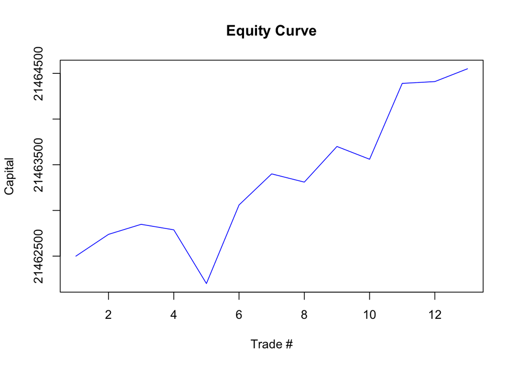

```r
initial_capital = (1/(0.02))*(1000 * sample(train$Open, 1)) # random price
capital <- initial_capital
drawdown <- c(capital)
wins <- c()

for (i in 1:nrow(test)) {
  pred_X <- predict(glm_step, test[i, ], type = "response")
  if (pred_X > best_threshold) {
    capital <- capital + test$pl_value[i]
    drawdown <- c(drawdown, capital)
    wins <- c(wins, test$pl_value[i])
  }
}

# Plot the equity curve
plot(drawdown, type = "l", col = "blue", main = "Equity Curve", ylab = "Capital", xlab = "Trade #")
```

```r
# Sharpe ratio (simplified version: mean return over SD of returns)
sharpe <- (tail(drawdown, 1) - initial_capital) / sd(wins)

# Maximum Drawdown Calculation
peak = max(drawdown)
trough = min(drawdown)
max_drawdown = (trough-peak)/peak


# Output results
cat("Initial Capital", initial_capital)
```

```
## Initial Capital 21462500
```

```r
cat("\nFinal Capital:", tail(drawdown, 1), "\n")
```

```
##
## Final Capital: 21464550
```

```r
cat("Sharpe Ratio:", round(sharpe, 3), "\n")
```

```
## Sharpe Ratio: 5.053
```

```r
cat("Max Drawdown:", max_drawdown*100, "\n")
```

```
## Max Drawdown: -0.01094934
```

```r
cat("Returns:", ((capital/initial_capital)-1)*100, "%\n")
```

```
## Returns: 0.009553513 %
```

## XGboost

In this section, we use **XGBoost**, a gradient-boosted decision tree ensemble, to classify trade direction. Our goal is not just accuracy but **precision**, the ratio of true positives to all predicted positives. This focus reduces false positives—critical for real-world trading where bad trades are costly.

### Load Data

We construct a design matrix using all two- and three-way interactions of trading indicators. The outcome variable `PL` is a binary indicator for whether a trade was profitable.

```r
library(xgboost)
library(Matrix)
library(caret)
data = train
X = model.matrix(PL ~ (ATR + SMA_k7 + SMA_k20 + SMA_k50 + norm_volume)^3, data=data)[, -1]
y = data$PL
dtrain = xgb.DMatrix(data = X, label = y)
```

### Cross-Validation and Training

We optimize for **AUC-PR** (area under the precision-recall curve), which directly measures precision vs. recall trade-offs.

```r
param_grid <- expand.grid(
  eta = 0.05,
  max_depth = 3,
  subsample = 0.8,
  colsample_bytree = 0.8,
  eval_metric = "aucpr",         # maximize precision-recall AUC
  objective = "binary:logistic"  # output probabilities
)

watchlist = list(train = dtrain)

model <- xgb.train(
  params = as.list(param_grid),
  data = dtrain,
  nrounds = 100,
  watchlist = watchlist,
  verbose = 0
)
```

### Threshold Selection Based on Precision

Rather than defaulting to a 0.5 decision threshold, we **optimize threshold** $T$ to maximize:

$$\text{Precision} = \frac{TP}{TP + FP}$$

We assume model predictions $\hat{y} \sim N(\mu, \sigma^2)$ and scan high quantiles (e.g., 0.99999) to reduce false positives.

```r
pred_probs <- predict(model, dtrain)
probs <- 10^seq(-2, -10, length.out = 9)

fit_mean = mean(pred_probs)
fit_sd = sd(pred_probs)

best_precision = 0
best_threshold = 0.5

for (prob in probs){
  threshold <- qnorm(1 - prob, mean = fit_mean, sd = fit_sd)
  preds = ifelse(pred_probs > threshold, 1, 0)
  TP = sum(preds == 1 & train$PL == 1)
  FP = sum(preds == 1 & train$PL == 0)
  if ((TP + FP) < 30) {
    break # CLT
  }
  precision = ifelse((TP + FP) == 0, NA, TP / (TP + FP))
  if (!is.na(precision) && precision > best_precision){
    best_precision = precision
    best_threshold = threshold
  }
}

cat("Best Precision:", round(best_precision * 100, 2), "% at Threshold", best_threshold, "\n")
```

```
## Best Precision: 83.67 % at Threshold 0.5804648
```

### Backtesting Equity Curve

Using the **test set**, we execute trades where the predicted probability $\hat{y} > T$, and track capital changes.

Let: - $C_0$: Initial capital - $r_i$: Profit/loss from trade $i$ - $T$: Threshold for high-precision entry

Then:
$$C_{i+1} = C_i + r_i \quad \text{only if } \hat{y}_i > T$$

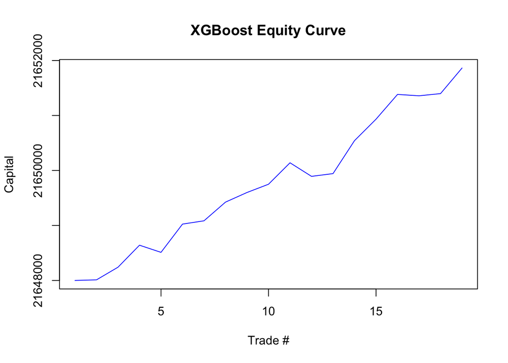

```r
test_X = model.matrix(PL ~ (ATR + SMA_k7 + SMA_k20 + SMA_k50 + norm_volume)^3, data=test)[, -1]
dtest = xgb.DMatrix(data = test_X)

pred_probs <- predict(model, dtest)

initial_capital = (1/(0.02)) * (1000 * sample(train$Open, 1))
capital = initial_capital
drawdown = c(capital)
wins = c()

for (i in 1:nrow(test)) {
  pred_X = pred_probs[i]
  if (pred_X > best_threshold) {
    capital = capital + test$pl_value[i]
    drawdown = c(drawdown, capital)
    wins = c(wins, test$pl_value[i])
  }
}

plot(drawdown, type="l", col="blue", main="XGBoost Equity Curve", ylab="Capital", xlab="Trade #")
```

```r
# Performance metrics
sharpe = (tail(drawdown, 1) - drawdown[1]) / sd(wins)
max_dd = min(drawdown - cummax(drawdown)) / max(drawdown)

cat("Final Capital:", capital, "\n")
```

```
## Final Capital: 21651863
```

```r
cat("Sharpe Ratio:", round(sharpe, 3), "\n")
```

```
## Sharpe Ratio: 16.043
```

```r
cat("Max Drawdown:", round(max_dd * 100, 2), "%\n")
```

```
## Max Drawdown: 0 %
```

### Commentary

XGBoost is particularly effective when: - Feature interactions matter - There are non-linear decision boundaries - **precision over recall**

Its ability to output probabilities makes it well-suited for **threshold tuning**, which we exploit using quantiles of the fitted distribution. By focusing on **extremely confident predictions**, we reduce bad trades and focus capital on high-reward setups.

## Linear Model Regressing on `pl_value`

This section introduces a **linear model** (LM) regressing on continuous profit/loss (`pl_value`). Unlike classification models (GLM/XGBoost), here we predict the **magnitude of returns**, not just the direction. This supports trading decisions by estimating expected trade value.

### Data Preparation

```r
lm1 <- lm(
  pl_value ~ ATR + SMA_k7 + SMA_k20 + SMA_k50 + norm_volume +
       ATR:SMA_k7 +
       ATR:SMA_k20 +
       ATR:SMA_k50 +
       ATR:SMA_k7:SMA_k20 +
       ATR:SMA_k7:SMA_k50 +
       ATR:SMA_k20:SMA_k50 +
       ATR:SMA_k7:SMA_k20:SMA_k50 +
       norm_volume:ATR +
       norm_volume:SMA_k7 +
       norm_volume:SMA_k20 +
       norm_volume:SMA_k50 +
       norm_volume:ATR:SMA_k7 +
       norm_volume:ATR:SMA_k20 +
       norm_volume:ATR:SMA_k50 +
       norm_volume:SMA_k7:SMA_k20 +
       norm_volume:SMA_k7:SMA_k50 +
       norm_volume:SMA_k20:SMA_k50 +
       norm_volume:ATR:SMA_k7:SMA_k20 +
       norm_volume:ATR:SMA_k7:SMA_k50 +
       norm_volume:ATR:SMA_k20:SMA_k50 +
       norm_volume:ATR:SMA_k7:SMA_k20:SMA_k50,
  data = train
)

# Perform AIC
lm1 <- step(lm1, direction = "both")
```

```
## Start:  AIC=160363.6
## pl_value ~ ATR + SMA_k7 + SMA_k20 + SMA_k50 + norm_volume + ATR:SMA_k7 +
##     ATR:SMA_k20 + ATR:SMA_k50 + ATR:SMA_k7:SMA_k20 + ATR:SMA_k7:SMA_k50 +
##     ATR:SMA_k20:SMA_k50 + ATR:SMA_k7:SMA_k20:SMA_k50 + norm_volume:ATR +
##     norm_volume:SMA_k7 + norm_volume:SMA_k20 + norm_volume:SMA_k50 +
##     norm_volume:ATR:SMA_k7 + norm_volume:ATR:SMA_k20 + norm_volume:ATR:SMA_k50 +
##     norm_volume:SMA_k7:SMA_k20 + norm_volume:SMA_k7:SMA_k50 +
##     norm_volume:SMA_k20:SMA_k50 + norm_volume:ATR:SMA_k7:SMA_k20 +
##     norm_volume:ATR:SMA_k7:SMA_k50 + norm_volume:ATR:SMA_k20:SMA_k50 +
##     norm_volume:ATR:SMA_k7:SMA_k20:SMA_k50
##
##
## Step:  AIC=160363.6
## pl_value ~ ATR + SMA_k7 + SMA_k20 + SMA_k50 + norm_volume + ATR:SMA_k7 +
##     ATR:SMA_k20 + ATR:SMA_k50 + ATR:norm_volume + SMA_k7:norm_volume +
##     SMA_k20:norm_volume + SMA_k50:norm_volume + ATR:SMA_k7:SMA_k20 +
##     ATR:SMA_k7:SMA_k50 + ATR:SMA_k20:SMA_k50 + ATR:SMA_k7:norm_volume +
##     ATR:SMA_k20:norm_volume + ATR:SMA_k50:norm_volume + SMA_k7:SMA_k20:norm_volume +
##     SMA_k7:SMA_k50:norm_volume + SMA_k20:SMA_k50:norm_volume +
##     ATR:SMA_k7:SMA_k20:SMA_k50 + ATR:SMA_k7:SMA_k20:norm_volume +
##     ATR:SMA_k7:SMA_k50:norm_volume + ATR:SMA_k20:SMA_k50:norm_volume
##
##
## Step:  AIC=160363.6
## pl_value ~ ATR + SMA_k7 + SMA_k20 + SMA_k50 + norm_volume + ATR:SMA_k7 +
##     ATR:SMA_k20 + ATR:SMA_k50 + ATR:norm_volume + SMA_k7:norm_volume +
##     SMA_k20:norm_volume + SMA_k50:norm_volume + ATR:SMA_k7:SMA_k20 +
##     ATR:SMA_k7:SMA_k50 + ATR:SMA_k20:SMA_k50 + ATR:SMA_k7:norm_volume +
##     ATR:SMA_k20:norm_volume + ATR:SMA_k50:norm_volume + SMA_k7:SMA_k20:norm_volume +
##     SMA_k7:SMA_k50:norm_volume + SMA_k20:SMA_k50:norm_volume +
##     ATR:SMA_k7:SMA_k20:norm_volume + ATR:SMA_k7:SMA_k50:norm_volume +
##     ATR:SMA_k20:SMA_k50:norm_volume
##
##                                   Df Sum of Sq       RSS    AIC
## - ATR:SMA_k7:SMA_k50:norm_volume   1         3 336256701 160362
## - ATR:SMA_k7:SMA_k20:norm_volume   1        10 336256708 160362
## <none>                                         336256698 160364
## - ATR:SMA_k20:SMA_k50:norm_volume  1     50987 336307685 160364
##
## Step:  AIC=160361.6
```

[output cut: 38 more lines]

```
##     ATR:SMA_k20 + ATR:SMA_k50 + ATR:norm_volume + SMA_k7:norm_volume +
##     SMA_k20:norm_volume + SMA_k50:norm_volume + ATR:SMA_k7:SMA_k20 +
##     ATR:SMA_k20:SMA_k50 + ATR:SMA_k7:norm_volume + ATR:SMA_k20:norm_volume +
##     ATR:SMA_k50:norm_volume + SMA_k7:SMA_k20:norm_volume + SMA_k7:SMA_k50:norm_volume +
##     SMA_k20:SMA_k50:norm_volume + ATR:SMA_k20:SMA_k50:norm_volume
##
##                                   Df Sum of Sq       RSS    AIC
## <none>                                         336284450 160359
## + ATR:SMA_k7:SMA_k50               1     27736 336256714 160360
## + ATR:SMA_k7:SMA_k20:norm_volume   1       113 336284337 160361
## - ATR:SMA_k20:SMA_k50:norm_volume  1    316965 336601415 160372
## - ATR:SMA_k7:SMA_k20               1    328373 336612823 160373
## - ATR:SMA_k7:norm_volume           1    584280 336868731 160385
## - SMA_k7:SMA_k20:norm_volume       1    790270 337074720 160395
## - SMA_k7:SMA_k50:norm_volume       1   1213895 337498345 160415
```

```r
summary(lm1)
```

```
##
## Call:
## lm(formula = pl_value ~ ATR + SMA_k7 + SMA_k20 + SMA_k50 + norm_volume +
##     ATR:SMA_k7 + ATR:SMA_k20 + ATR:SMA_k50 + ATR:norm_volume +
##     SMA_k7:norm_volume + SMA_k20:norm_volume + SMA_k50:norm_volume +
##     ATR:SMA_k7:SMA_k20 + ATR:SMA_k20:SMA_k50 + ATR:SMA_k7:norm_volume +
##     ATR:SMA_k20:norm_volume + ATR:SMA_k50:norm_volume + SMA_k7:SMA_k20:norm_volume +
##     SMA_k7:SMA_k50:norm_volume + SMA_k20:SMA_k50:norm_volume +
##     ATR:SMA_k20:SMA_k50:norm_volume, data = train)
##
## Residuals:
##     Min      1Q  Median      3Q     Max
## -974.57  -91.87  -21.93   91.07 1612.44
##
## Coefficients:
##                                   Estimate Std. Error t value Pr(>|t|)
## (Intercept)                      5.284e+02  5.687e+03   0.093 0.925973
## ATR                              3.134e+07  6.300e+06   4.975 6.59e-07 ***
## SMA_k7                          -2.114e+04  9.277e+03  -2.278 0.022718 *
## SMA_k20                          3.364e+04  9.332e+03   3.604 0.000314 ***
## SMA_k50                         -1.303e+04  4.512e+03  -2.888 0.003888 **
## norm_volume                     -8.163e+06  1.922e+06  -4.247 2.18e-05 ***
## ATR:SMA_k7                      -3.210e+07  8.127e+06  -3.950 7.84e-05 ***
## ATR:SMA_k20                     -3.157e+07  6.298e+06  -5.013 5.40e-07 ***
## ATR:SMA_k50                      1.028e+06  4.138e+06   0.248 0.803878
## ATR:norm_volume                  9.356e+06  2.387e+06   3.919 8.92e-05 ***
## SMA_k7:norm_volume              -1.095e+07  2.551e+06  -4.291 1.79e-05 ***
## SMA_k20:norm_volume              3.929e+07  4.849e+06   8.103 5.75e-16 ***
## SMA_k50:norm_volume             -1.204e+07  2.658e+06  -4.529 5.96e-06 ***
## ATR:SMA_k7:SMA_k20               3.220e+07  8.121e+06   3.965 7.38e-05 ***
## ATR:SMA_k20:SMA_k50             -8.906e+05  4.141e+06  -0.215 0.829722
## ATR:SMA_k7:norm_volume          -1.523e+05  2.879e+04  -5.288 1.25e-07 ***
## ATR:SMA_k20:norm_volume         -9.045e+06  2.379e+06  -3.802 0.000144 ***
## ATR:SMA_k50:norm_volume         -9.479e+06  2.397e+06  -3.954 7.71e-05 ***
## SMA_k7:SMA_k20:norm_volume      -2.021e+07  3.285e+06  -6.150 7.91e-10 ***
## SMA_k7:SMA_k50:norm_volume       3.120e+07  4.094e+06   7.623 2.62e-14 ***
## SMA_k20:SMA_k50:norm_volume     -1.914e+07  2.425e+06  -7.892 3.16e-15 ***
## ATR:SMA_k20:SMA_k50:norm_volume  9.321e+06  2.393e+06   3.895 9.85e-05 ***
## ---
## Signif. codes:  0 '***' 0.001 '**' 0.01 '*' 0.05 '.' 0.1 ' ' 1
##
## Residual standard error: 144.5 on 16097 degrees of freedom
## Multiple R-squared:  0.01591,    Adjusted R-squared:  0.01462
## F-statistic: 12.39 on 21 and 16097 DF,  p-value: < 2.2e-16
```

### Residual Analysis

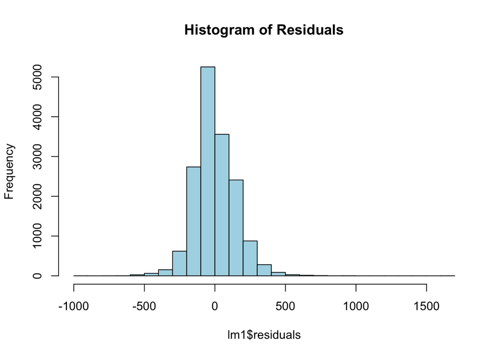

```r
hist(lm1$residuals, main="Histogram of Residuals", col="lightblue", breaks=30)
```

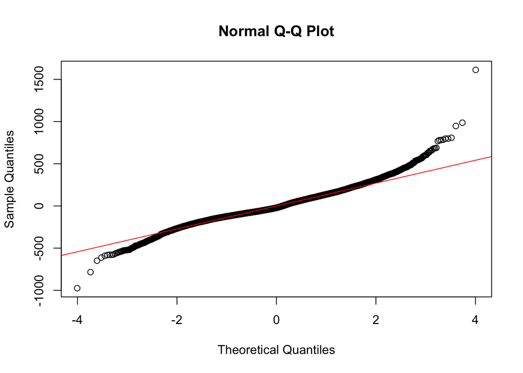

```r
qqnorm(lm1$residuals)
qqline(lm1$residuals, col = "red")
```

The Q-Q plot reveals the data is heavy tailed. Trimming outliers might be beneficial here.

For this we should use robust linear regression which is able to downweight outliers

```r
library(MASS)
lm_robust <- rlm(
  lm1$terms,
  data = train
)
summary(lm_robust)
```

```
##
## Call: rlm(formula = lm1$terms, data = train)
## Residuals:
##     Min      1Q  Median      3Q     Max
## -919.76  -87.61  -19.93   94.97 1616.78
##
## Coefficients:
##                                 Value         Std. Error    t value
## (Intercept)                      3.529365e+03  5.301468e+03  6.657000e-01
## ATR                              2.172274e+07  5.873323e+06  3.698500e+00
## SMA_k7                          -2.240869e+04  8.648602e+03 -2.591000e+00
## SMA_k20                          2.302365e+04  8.699703e+03  2.646500e+00
## SMA_k50                         -4.142966e+03  4.205981e+03 -9.850000e-01
## norm_volume                     -4.255340e+06  1.792004e+06 -2.374600e+00
## ATR:SMA_k7                      -2.093347e+07  7.576480e+06 -2.763000e+00
## ATR:SMA_k20                     -2.191424e+07  5.870813e+06 -3.732700e+00
## ATR:SMA_k50                     -5.886416e+05  3.857919e+06 -1.526000e-01
## ATR:norm_volume                  7.432722e+06  2.225527e+06  3.339800e+00
## SMA_k7:norm_volume              -1.350695e+07  2.378428e+06 -5.678900e+00
## SMA_k20:norm_volume              3.912385e+07  4.520681e+06  8.654400e+00
## SMA_k50:norm_volume             -1.712465e+07  2.478004e+06 -6.910700e+00
## ATR:SMA_k7:SMA_k20               2.103305e+07  7.570651e+06  2.778200e+00
## ATR:SMA_k20:SMA_k50              6.805037e+05  3.860370e+06  1.763000e-01
## ATR:SMA_k7:norm_volume          -1.066188e+05  2.683951e+04 -3.972500e+00
## ATR:SMA_k20:norm_volume         -7.185761e+06  2.217917e+06 -3.239900e+00
## ATR:SMA_k50:norm_volume         -7.537247e+06  2.234818e+06 -3.372600e+00
## SMA_k7:SMA_k20:norm_volume      -2.138214e+07  3.062694e+06 -6.981500e+00
## SMA_k7:SMA_k50:norm_volume       3.492812e+07  3.816150e+06  9.152700e+00
## SMA_k20:SMA_k50:norm_volume     -1.778289e+07  2.261044e+06 -7.864900e+00
## ATR:SMA_k20:SMA_k50:norm_volume  7.396944e+06  2.230785e+06  3.315800e+00
##
## Residual standard error: 134.5 on 16097 degrees of freedom
```

### Precision Evaluation of LM

We define precision here as the model’s **ability to correctly predict profitable trades**. Let $\hat{y}$ be the predicted `pl_value`. A trade is considered positive if $\hat{y} > 0$.

Let:

- TP: $\hat{y} > 0$ and actual $y > 0$
- FP: $\hat{y} > 0$ but actual $y \le 0$

$$\text{Precision} = \frac{TP}{TP + FP}$$

```r
pred_lm = predict(lm_robust, train)

TP = sum(pred_lm > 0 & train$pl_value > 0)
FP = sum(pred_lm > 0 & train$pl_value <= 0)
precision = TP / (TP + FP)

cat("TP:", TP, "FP:", FP, "\n")
```

```
## TP: 1974 FP: 2383
```

```r
cat("Precision:", round(precision, 4), "\n")
```

```
## Precision: 0.4531
```

### Adjusting Buy Threshold

We adjust the threshold $T$ such that:
$$\text{Buy only if } \hat{y} > T$$

This helps **reduce false positives**. Based on central limit theorem assumptions, we want at least 30 trades

```r
thresholds <- seq(0, max(lm_robust$fitted.values), by = 1)
results <- data.frame()

for (T in thresholds) {
  TP = sum(pred_lm > T & train$pl_value > 0)
  FP = sum(pred_lm > T & train$pl_value <= 0)
  precision = ifelse((TP + FP) == 0, NA, TP / (TP + FP))
  count = TP + FP
  if (count < 30){
    break
  }
  results = rbind(results, data.frame(threshold=T, TP=TP, FP=FP, Precision=precision, Trades=count))
}

tail(results)
```

```
##    threshold TP FP Precision Trades
## 74        73 22 13 0.6285714     35
## 75        74 22 12 0.6470588     34
## 76        75 22 11 0.6666667     33
## 77        76 22 11 0.6666667     33
## 78        77 22 10 0.6875000     32
## 79        78 20 10 0.6666667     30
```

### Backtest

```r
pred_lm = predict(lm_robust, test)
best_row = results[which.max(results$Precision), ]
best_threshold = best_row$threshold
cat("Best threshold for precision:", best_threshold, "\n")
```

```
## Best threshold for precision: 77
```

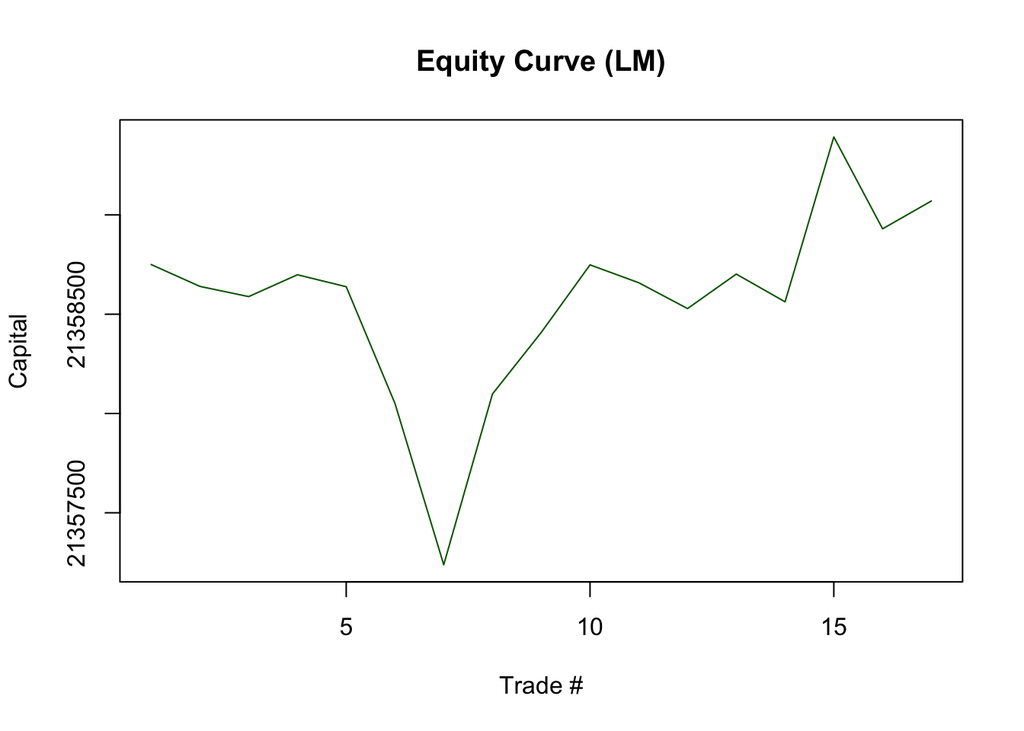

```r
capital = (1/(0.02)) * (1000 * sample(train$Open, 1))
drawdown = c(capital)
wins = c()

for (i in 1:nrow(test)) {
  pred = pred_lm[i]
  if (pred > best_threshold) {
    capital = capital + test$pl_value[i]
    drawdown = c(drawdown, capital)
    wins = c(wins, test$pl_value[i])
  }
}

plot(drawdown, type = "l", col = "darkgreen", main = "Equity Curve (LM)", ylab = "Capital", xlab = "Trade #")
```

```r
sharpe = (tail(drawdown, 1) - drawdown[1]) / sd(wins)
max_dd = min(drawdown - cummax(drawdown)) / max(drawdown)

cat("Final Capital:", capital, "\n")
```

```
## Final Capital: 21359070
```

```r
cat("Sharpe Ratio:", round(sharpe, 3), "\n")
```

```
## Sharpe Ratio: 0.718
```

```r
cat("Max Drawdown:", round(max_dd * 100, 2), "%\n")
```

```
## Max Drawdown: -0.01 %
```

# Final Thoughts

We have now explored **three models** in depth:

| Model | Output Type | Thresholding | Precision Tuning | Purpose |
| --- | --- | --- | --- | --- |
| Logistic Regression (GLM) | Probabilities (binary) | Yes | Yes via qnorm thresholds | Predict trade direction |
| XGBoost | Probabilities (binary) | Yes | Yes via precision-optimized threshold | Precision-focused execution |
| Linear Regression (LM) | Continuous (`pl_value`) | Yes | Yes via trade value cutoffs | Forecast trade magnitude |

In trading, minimizing **false positives** is often more critical than maximizing true positives due to the **asymmetric cost of bad trades**. While GLM offers interpretability and XGBoost offers nonlinear flexibility, the linear model offers continuous signal strength which supports **position sizing** and **expected value filtering**.

For high-frequency or precision-critical applications, combining these models in an ensemble or using their outputs as **features for meta-learning** may offer further benefits.